# Practical

## Generalised Additive Model

In this practical we will:

- Learn how to fit a GAM with `inlabru`
- Generate predictions from the model

Generalised Additive Models (GAMs) are very similar to linear models, but with an additional basis set that provides flexibility.

Additive models are a general form of statistical model which allows us to incorporate smooth functions alongside linear terms. A general expression for the linear predictor of a GAM is given by

$$\eta_i = g(\mu_i) = \beta_0 + \sum_{j=1}^L f_j(x_{ij})$$

where the mean $\pmb{\mu} = E(\mathbf{y}|\mathbf{x}_1,\ldots,\mathbf{x}_L)$ and $g()$ is a link function (notice that the distribution of the response and the link between the predictors and this distribution can be quite general). The term $f_j()$ is a smooth function for the *j*-th explanatory variable that can be represented as

$$f(x_i) = \sum_{k=0}^q\beta_k b_k(x_i)$$

where $b_k$ denote the basis functions and $\beta_K$ are their coefficients.

Increasing the number of basis functions leads to a more *wiggly* line. Too few basis functions might make the line too smooth, too many might lead to overfitting.To avoid this, we place further constraints on the spline coefficients which leads to constrained optimization problem where the objective function to be minimized is given by:

$$\mathrm{min}\sum_i(y_i-f(x_i))^2 + \lambda(\sum_kb^2_k)$$
The first term measures how close the function $f()$ is to the data while the second term $\lambda(\sum_kb^2_k)$, penalizes the roughness in the function. Here, $lambda >0$ is known as the smoothing parameter because it controls the degree of smoothing (i.e. the trade-off between the two terms). In a Bayesian setting,including the penalty term is equivalent to setting a specific prior on the coefficients of the covariates.

In this exercise we will set a random walk prior of order 1 on $f$, i.e. $f(x_i)-f(x_i-1) \sim \mathcal{N}(0,\sigma^2_f)$ where $\sigma_f^2$ is the smoothing parameter such that small values give large smoothing. Notice that we will assume $x_i$’s are equally spaced for now (we will cover a stochastic differential equation approach that relaxes this assumption later on in the course).

### Simulate Data

Lets generate some data so evaluate how RW models perform when estimating a smooth curve. The data are simulated from the following model:

$$y_i = 1 + \mathrm{cos}(x) + \epsilon_i, ~ \epsilon_i \sim \mathcal{N}(0,\sigma^2_\epsilon)$$
where $\sigma_\epsilon^2 = 0.25$

```r
n = 100
x = rnorm(n)
eta = (1 + cos(x))
y = rnorm(n, mean =  eta, sd = 0.5)

df = data.frame(y = y,
                x_smooth = inla.group(x))
```

### Fitting a GAM in `inlabru`

Now lets fit a flexible model by setting a random walk of order 1 prior on the coefficients. This can be done bye specifying `model = "rw1"` in the model component (similarly,a random walk of order 2 can be placed by setting `model = "rw2"` )

```r
cmp =  ~ Intercept(1) +
  smooth(x_smooth, model = "rw1")
```

Now we define the observational model:

```r
lik =  bru_obs(formula = y ~.,
            family = "gaussian",
            data = df)
```

We then can fit the model:

```r
fit = bru(cmp, lik)
fit$summary.fixed
```

```
              mean         sd 0.025quant 0.5quant 0.975quant     mode
Intercept 1.266765 0.06297536   1.143964 1.266439    1.39143 1.266444
                   kld
Intercept 1.399606e-08
```

The posterior summary regarding the estimated function using RW1 can be accessed through `fit$summary.random$smooth`, the output includes the value of $x_i$ (`ID`) as well as the posterior mean, standard deviation, quantiles and mode of each $f(x_i)$. We can use this information to plot the posterior mean and associated 95% credible intervals.

**R plot**

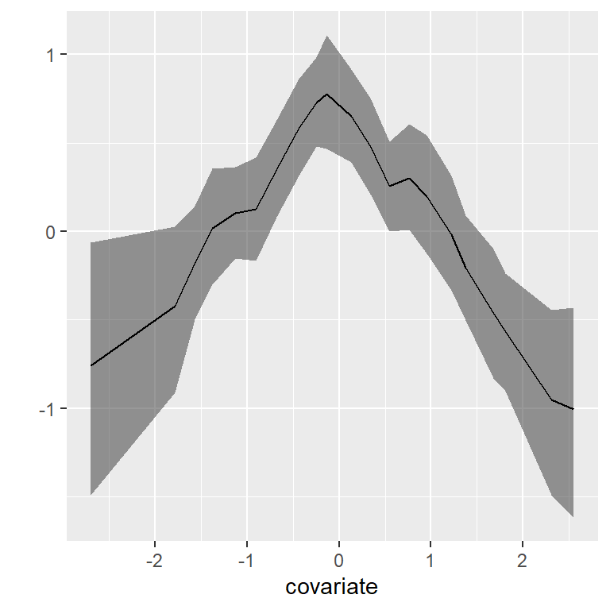

Smooth effect of the covariate

**R Code**

```r
data.frame(fit$summary.random$smooth) %>%
  ggplot() +
  geom_ribbon(aes(ID,ymin = X0.025quant, ymax= X0.975quant), alpha = 0.5) +
  geom_line(aes(ID,mean)) +
  xlab("covariate") + ylab("")
```

### Model Predictions

We can obtain the model predictions using the `predict` function.

```r
pred = predict(fit, df, ~ (Intercept + smooth))
```

The we can plot them together with the true curve and data points:

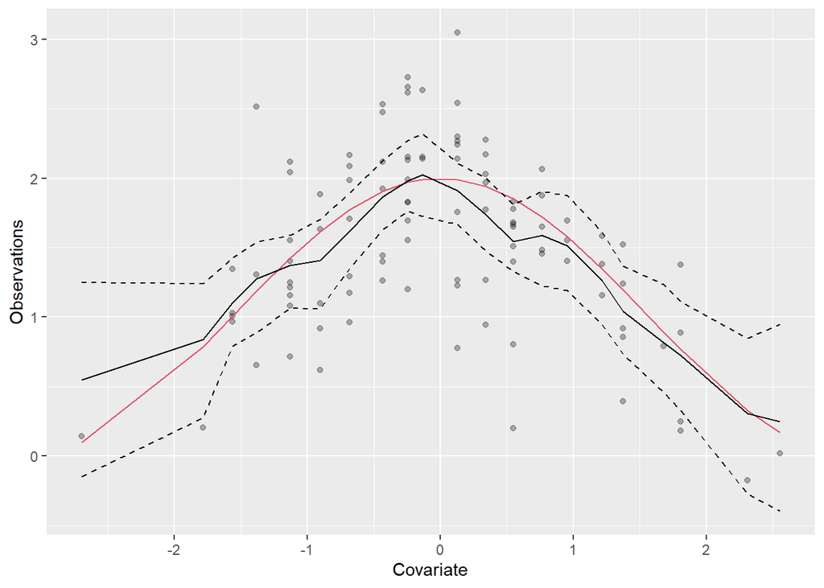

Data and 95% credible intervals

```r
pred %>% ggplot() +
  geom_point(aes(x_smooth,y), alpha = 0.3) +
  geom_line(aes(x_smooth,1+cos(x_smooth)),col=2)+
  geom_line(aes(x_smooth,mean)) +
  geom_line(aes(x_smooth, q0.025), linetype = "dashed")+
  geom_line(aes(x_smooth, q0.975), linetype = "dashed")+
  xlab("Covariate") + ylab("Observations")
```